# Lab7Complete

Author

Sebastian Boksem

```r
library(tidyverse)
```

## Importing Data Set

```r
BlackfootFish <- read_csv(here::here("supporting_artifacts", "Lab7", "BlackfootFish.csv"))
```

## Finding Any Variables With Missing Columns

```r
BlackfootFish |>
   summarize(
     across(trip:species, is.na)
        ) |>
  summarize(across(trip:species, sum))
```

```
# A tibble: 1 × 7
   trip  mark length weight  year section species
  <int> <int>  <int>  <int> <int>   <int>   <int>
1     0     0      0   1796     0       0       0
```

Weight would be the only variable with NA values. It contains 1796 observations.

## Visualizing Missing Data

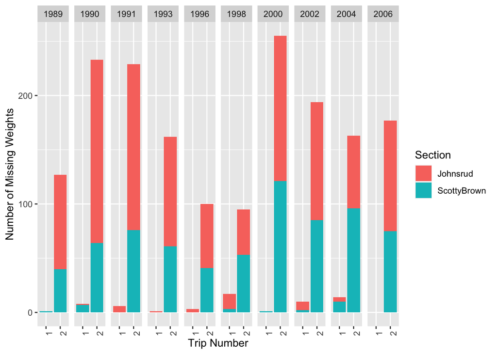

```r
BlackfootFish |>
   mutate(checkna = is.na(weight)
   ) |>
  group_by(year, section, trip) |>
  summarize(sum(checkna)) |>
  rename(missing = `sum(checkna)`) |>
  mutate(
    trip = as.factor(trip)
  ) |>
  ggplot() +
  geom_col(mapping = aes(x = trip,y = missing, fill = section)) +
  facet_grid(. ~ year) +
  theme(axis.text.x = element_text(angle = 90)) +
  labs(
       x = "Trip Number",
       y = "Number of Missing Weights",
       fill = "Section")
```

From this vizualization, it seems like Johnsrud is the responsible section for the most missing data. Years 1990, 1991, and 2000 seem to be most notable in the losing of data. The biggest difference is that trip 2 seems to be the most frequent in missing data.

## Writing a Function

```r
rescale_01 <- function(y){
  range <- range(y)
  y_scaled <- (y - range[1])/(range[2]-range[1])
  return(y_scaled)
}
```

## Adding Stops

```r
rescale_01 <- function(y){
  stopifnot(is.numeric(y),
            length(y) > 1
            )
  range <- range(y, na.rm = TRUE)
  y_scaled = (y - range[1])/(range[2]-range[1])
  return(y_scaled)
}
```

## Testing

```r
x <- c(1:25, NA)
range(rescale_01(x), na.rm = TRUE)
```

```
[1] 0 1
```

# **REFLECTION:**

**From the previous attempt, I changed the histogram from the normal one in base R into the ggplot one that utilizes a newly created data set for the two different lengths. I have also in addition have changed the layout of the quarto chunk allowing the two graphs to be shown side by side. I feel like this revision has taught me that histograms exist within ggplot and seem to be much easier to use than the one in base R. For future use I will try and utilize it more as an explanation/visualization for single variable graphs. I feel like I have also learned more about how to format Quarto chunks and as a result I think i will format any multiple graphs that are created in the same chunk to be side by side.**

## Performing a More Difficult Test

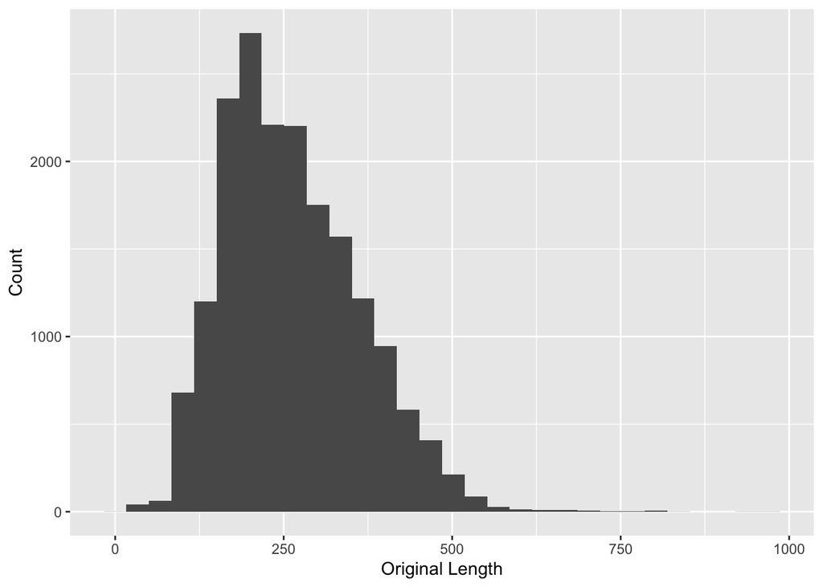

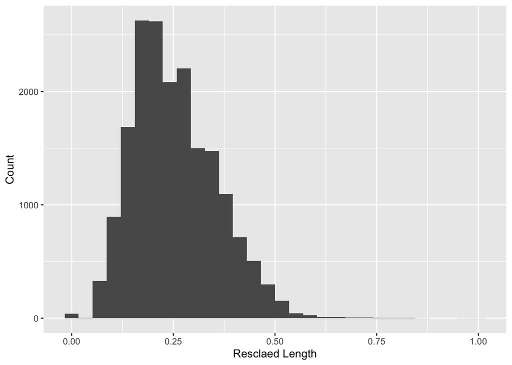

```r
length <- BlackfootFish$length
Rescaled_Length <- rescale_01(length)
Comparison_lengths <- data.frame(length, Rescaled_Length)
Comparison_lengths |>
  ggplot(mapping = aes(x = length)) +
  geom_histogram() +
  labs(x = 'Original Length', y = 'Count')
Comparison_lengths |>
  ggplot(mapping = aes(x = Rescaled_Length)) +
  geom_histogram()  +
  labs(x = 'Resclaed Length', y = 'Count')
```

```r
rescale_column <- function(df, c){
  stopifnot(is.data.frame(df))

  df |>
    dplyr::mutate(
      across(
        .cols = {{c}},
        .fns = rescale_01
))
}
rescale_column(BlackfootFish, c('length', 'weight'))
```

```
# A tibble: 18,352 × 7
    trip  mark length  weight  year section  species
   <dbl> <dbl>  <dbl>   <dbl> <dbl> <chr>    <chr>
 1     1     0  0.280 0.0374   1989 Johnsrud RBT
 2     1     0  0.280 0.0406   1989 Johnsrud RBT
 3     1     0  0.277 0.0524   1989 Johnsrud RBT
 4     1     0  0.315 0.0588   1989 Johnsrud RBT
 5     1     0  0.305 0.0641   1989 Johnsrud RBT
 6     1     0  0.358 0.0812   1989 Johnsrud RBT
 7     1     0  0.261 0.0363   1989 Johnsrud RBT
 8     1     0  0.148 0.00855  1989 Johnsrud RBT
 9     1     0  0.203 0.0171   1989 Johnsrud RBT
10     1     0  0.145 0.00748  1989 Johnsrud RBT
# … with 18,342 more rows
```